# cm005

## Preliminary

Begin by loading the required packages. If you don’t have these installed (or don’t know whether you have them installed), you can install them by executing the following code in your console:

```
install.packages("tidyverse")
install.packages("scales")
install.packages("tsibble")
```

Now run this code chunk to load the packages:

```r
suppressPackageStartupMessages(library(tidyverse))
suppressPackageStartupMessages(library(gapminder))
suppressPackageStartupMessages(library(scales))
suppressPackageStartupMessages(library(tsibble))
knitr::opts_chunk$set(fig.align = "center")
```

## Exercise 1: Bar Chart Grammar (Together)

Consider the following plot. Don’t concern yourself with the code at this point.

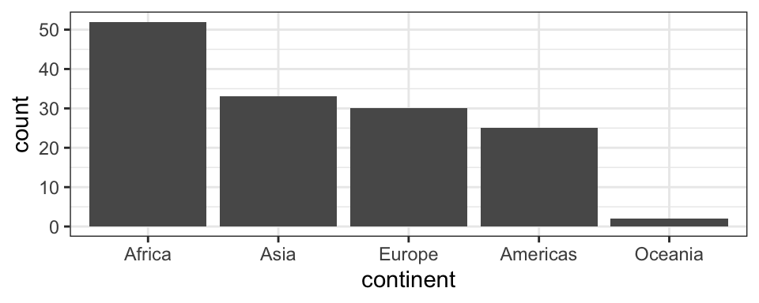

```r
gapminder %>%
  filter(year == 2007) %>%
  mutate(continent = fct_infreq(continent)) %>%
  ggplot(aes(continent)) +
  geom_bar() +
  theme_bw()
```

Fill in the seven grammar components for this plot.

| Grammar Component | Specification |
| --- | --- |
| **data** | `gapminder` |
| **aesthetic mapping** | `x=continent, y=count` |
| **geometric object** | `bar` |
| scale | `linear` |
| statistical transform | `count` |
| coordinate system | `cartesian` |
| facetting | `no` |

## Exercise 2: `ggplot2` Syntax (Your Turn)

The following is a tsibble (a special type of tibble containing time series data, which we’ll see more of later), stored in the variable `mauna`, of CO$_2$ concentrations collected monthly at the Mauna Loa station.

Execute this code to store the data in `mauna`:

```r
(mauna <- tsibble::as_tsibble(co2) %>%
   rename(month = index, conc = value))
```

```
## # A tsibble: 468 x 2 [1M]
##       month  conc
##       <mth> <dbl>
##  1 1959 Jan  315.
##  2 1959 Feb  316.
##  3 1959 Mar  316.
##  4 1959 Apr  318.
##  5 1959 May  318.
##  6 1959 Jun  318
##  7 1959 Jul  316.
##  8 1959 Aug  315.
##  9 1959 Sep  314.
## 10 1959 Oct  313.
## # … with 458 more rows
```

### 2(a)

Produce a line chart showing the concentration over time. Specifically, the plot should have the following grammar components:

| Grammar Component | Specification |
| --- | --- |
| **data** | `mauna` |
| **aesthetic mapping** | x: month, y: conc |
| **geometric object** | lines |
| scale | linear |
| statistical transform | none |
| coordinate system | rectangular |
| facetting | none |

Fill in the blanks to obtain the plot:

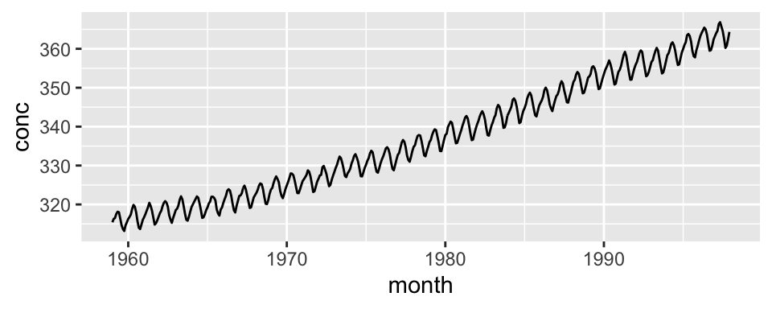

```r
ggplot(mauna, aes(month, conc)) +
  geom_line()
```